# PAGe v3 2026–27 Walk-Forward Review: weekF8–11

M0 ignition, M1 timing, and M2 forecast diagnostics

Author

PAGe

Published

September 28, 2026

## Executive summary

This report shows the 2026–27 PAGe v3 walk-forward state from **weekF8 through weekF11**, the latest available week in the current OLIS panel.

> **Governance note:** weekF8–11 are **pre-issuance diagnostics**. The canonical v3 lower bound is now **weekF12**. Numerical M2 values shown here are retrospective walk-forward diagnostics generated from information available at each origin; they were **not governed issued forecasts**.

As of weekF11 (week ending 2026-09-19):

- Flu A positivity was **1.743%**.
- Flu B positivity was **0.0306%**.
- **M0-A had not ignited** at any origin from weekF8–11.
- **M1-A remained pre-ignition**; no A peak-timing state was active.
- **M1-B remained outside its weekF12 timing window**; no B timing event was active.
- M2 state forecasts were nevertheless computable for diagnostic replay. Through targets already observed by weekF11, the to-date MAE was **0.412 pp for A+1** and **0.028 pp for B+1**.

## Observed surveillance signal

| weekF | week start | week end | A positivity (%) | B positivity (%) |
| --- | --- | --- | --- | --- |
| 8 | 2026-08-23 | 2026-08-29 | 0.736 | 0.0744 |
| 9 | 2026-08-30 | 2026-09-05 | 1.321 | 0.0513 |
| 10 | 2026-09-06 | 2026-09-12 | 1.848 | 0.0167 |
| 11 | 2026-09-13 | 2026-09-19 | 1.743 | 0.0306 |

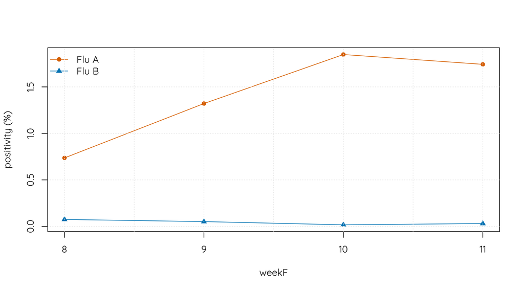

Observed A and B positivity through weekF11.

## M0: A ignition walk-forward

M0 was evaluated prospectively at each origin using only data available through that week. Across weekF8–11, the detector did **not** fire.

| origin weekF | A ignited? | estimated ignition weekF |
| --- | --- | --- |
| 8 | FALSE | — |
| 9 | FALSE | — |
| 10 | FALSE | — |
| 11 | FALSE | — |

Interpretation: the increase in A positivity by weekF9–10 was not sufficient to satisfy the frozen M0 ignition rules. There was therefore no M0-to-M1 ignition handoff during these origins.

## M1: timing state

### Influenza A

Because M0 had not ignited, M1-A stayed inactive/pre-ignition throughout the review window.

### Influenza B

The canonical B timing/activity lower bound is now weekF12. Therefore weekF8–11 are explicitly **pre-window**, with no B timing event or passage posterior available.

| origin weekF | M1-A state | A peak weekF | A P(peak passed) | M1-B state | B activity weekF | B reason |
| --- | --- | --- | --- | --- | --- | --- |
| 8 | inactive_pre_ignition | — | — | inactive_no_timing_event | — | pre_window |
| 9 | inactive_pre_ignition | — | — | inactive_no_timing_event | — | pre_window |
| 10 | inactive_pre_ignition | — | — | inactive_no_timing_event | — | pre_window |
| 11 | inactive_pre_ignition | — | — | inactive_no_timing_event | — | pre_window |

## M2: walk-forward forecast diagnostics

The table below reports what the frozen state models would have predicted using only information available at each origin. These are **diagnostic replay values**, not issued forecasts, because all origins are before weekF12.

- A +1/+2 route: exact A1 state model.
- B +1 route: exact B1 state model.
- B +2 route: exact B1 fallback because B timing is unavailable before weekF12.

| origin | origin week end | type | horizon | target | forecast (%) | observed (%) | error (pp) | abs error (pp) | route |
| --- | --- | --- | --- | --- | --- | --- | --- | --- | --- |
| 8 | 2026-08-29 | A | 1 | 9 | 0.8672 | 1.3209 | -0.4538 | 0.4538 | exact_A1_state_diagnostic |
| 8 | 2026-08-29 | A | 2 | 10 | 0.8623 | 1.8482 | -0.9859 | 0.9859 | exact_A1_state_diagnostic |
| 8 | 2026-08-29 | B | 1 | 9 | 0.0873 | 0.0513 | 0.0360 | 0.0360 | exact_B1_state_diagnostic |
| 8 | 2026-08-29 | B | 2 | 10 | 0.0908 | 0.0167 | 0.0741 | 0.0741 | exact_B1_fallback_diagnostic |
| 9 | 2026-09-05 | A | 1 | 10 | 1.8743 | 1.8482 | 0.0261 | 0.0261 | exact_A1_state_diagnostic |
| 9 | 2026-09-05 | A | 2 | 11 | 1.8638 | 1.7427 | 0.1211 | 0.1211 | exact_A1_state_diagnostic |
| 9 | 2026-09-05 | B | 1 | 10 | 0.0508 | 0.0167 | 0.0341 | 0.0341 | exact_B1_state_diagnostic |
| 9 | 2026-09-05 | B | 2 | 11 | 0.0528 | 0.0306 | 0.0222 | 0.0222 | exact_B1_fallback_diagnostic |
| 10 | 2026-09-12 | A | 1 | 11 | 2.4994 | 1.7427 | 0.7567 | 0.7567 | exact_A1_state_diagnostic |
| 10 | 2026-09-12 | A | 2 | 12 | 2.4854 | — | — | — | exact_A1_state_diagnostic |
| 10 | 2026-09-12 | B | 1 | 11 | 0.0153 | 0.0306 | -0.0154 | 0.0154 | exact_B1_state_diagnostic |
| 10 | 2026-09-12 | B | 2 | 12 | 0.0159 | — | — | — | exact_B1_fallback_diagnostic |
| 11 | 2026-09-19 | A | 1 | 12 | 1.6773 | — | — | — | exact_A1_state_diagnostic |
| 11 | 2026-09-19 | A | 2 | 13 | 1.6679 | — | — | — | exact_A1_state_diagnostic |
| 11 | 2026-09-19 | B | 1 | 12 | 0.0312 | — | — | — | exact_B1_state_diagnostic |
| 11 | 2026-09-19 | B | 2 | 13 | 0.0325 | — | — | — | exact_B1_fallback_diagnostic |

### Score to date

Only targets already observed by weekF11 can be scored. Therefore:

- weekF8 contributes +1 and +2 targets;
- weekF9 contributes +1 and +2 targets;
- weekF10 contributes +1 only;
- weekF11 forecasts are not yet scoreable.

| type | horizon | MAE (pp) | n scored |
| --- | --- | --- | --- |
| A | 1 | 0.4122 | 3 |
| B | 1 | 0.0285 | 3 |
| A | 2 | 0.5535 | 2 |
| B | 2 | 0.0481 | 2 |

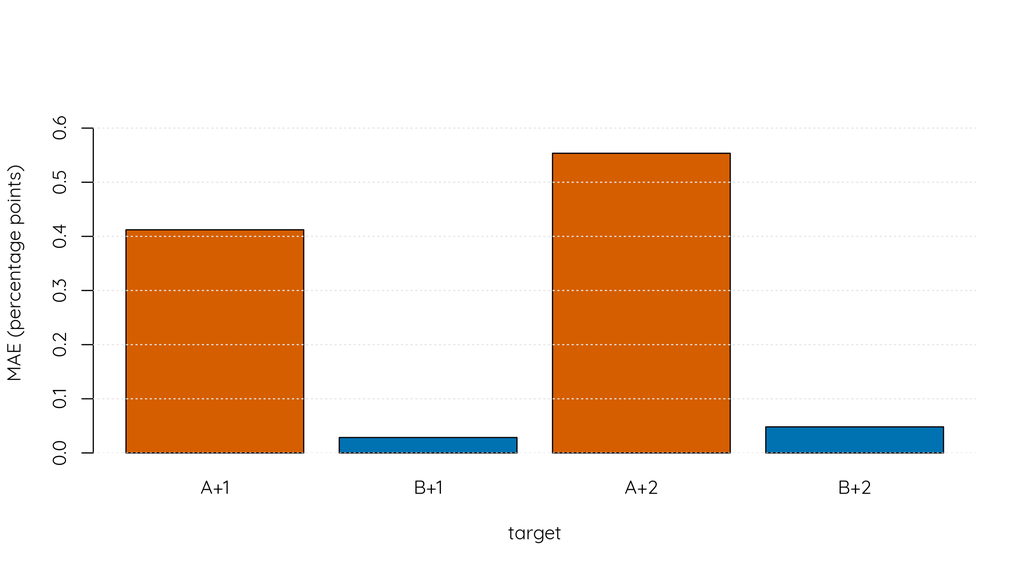

Walk-forward MAE to date for targets realized by weekF11.

## Origin-by-origin notes

| weekF | A obs % | B obs % | M0-A | M1-A | M1-B | A+1 % | A+2 % | B+1 % | B+2 % |
| --- | --- | --- | --- | --- | --- | --- | --- | --- | --- |
| 8 | 0.7362 | 0.0744 | not ignited | inactive_pre_ignition | inactive_no_timing_event / pre_window | 0.8672 | 0.8623 | 0.0873 | 0.0908 |
| 9 | 1.3209 | 0.0513 | not ignited | inactive_pre_ignition | inactive_no_timing_event / pre_window | 1.8743 | 1.8638 | 0.0508 | 0.0528 |
| 10 | 1.8482 | 0.0167 | not ignited | inactive_pre_ignition | inactive_no_timing_event / pre_window | 2.4994 | 2.4854 | 0.0153 | 0.0159 |
| 11 | 1.7427 | 0.0306 | not ignited | inactive_pre_ignition | inactive_no_timing_event / pre_window | 1.6773 | 1.6679 | 0.0312 | 0.0325 |

## Legacy / v2 / v3 context

These weekF8–11 rows are **v3 pre-issuance diagnostics**, not issued forecasts. Historical model comparisons therefore remain separate from this prospective report.

- On the matched M1 common ledger in `artifacts/m1-v2-lowrank-posterior-v10-release-consistent/common_ledger_vs_legacy_v16_strict_future_release.csv`, v2 mean absolute peak error is about **1.093 weeks** versus **1.375 weeks** for legacy across 81 common origin/truth rows in 10 seasons. This is an M1 timing comparison only.
- A direct matched-target-ledger legacy/v2 M2-A benchmark is available under `artifacts/m2-v2-legacy-matched-a-v1/`; its primary 10-season comparison uses identical target counts but not perfectly identical training vintages.
- Canonical v2/v3 operational comparisons begin at weekF12 and must come from `2026/run_weekly_shadow_release_v5.R`, which runs both systems from the same archived source and effective typed panel. Transaction deltas describe model-output differences, not forecast accuracy until the target is observed.
- No verified common-ledger legacy/v2 M0 performance comparison is claimed here.

### WeekF12 A-ignition diagnostic

The frozen M0-A detector uses `w_min=12` and a 1-SE sampling-noise tolerance for recent raw-positivity drops. The weekF10→11 decrease is therefore still classified as raw-step stable. A direct diagnostic that appends the current M2 weekF12 A projection (~1.677%) to the observed weekF1–11 history returns **M0 ignition at weekF12**. This is a counterfactual model-state check, not an observed weekF12 result.

See `docs/v3-legacy-v2-v3-comparison-plan-2026-09-28.md` for the comparison contract.

## Governance and provenance

| item | value |
| --- | --- |
| Season | 2026-27 |
| Walk-forward origins | 8,9,10,11 |
| Latest available weekF | 11 |
| Latest available week end | 2026-09-19 |
| Canonical forecast release | 5472d08992b5a9da40a9419b75c7427847ff7b1999070041d5e38b0a71da853b |
| Typed-panel SHA-256 | b5d8b14ad8c44af85a937fdc74f9fcf6738a1408399505f65e189c21cc10f390 |
| Effective-panel SHA-256 | 02475cc1c10999ee3ff810f273a5074903f7ada71177d5e14b261e2b377c84d9 |
| Governed minimum forecast origin | 12 |
| Report status | diagnostic_walkforward_pre_issuance |

The model-state and M2 diagnostic CSVs are generated by:

`../scripts/v3_generate_week8_11_walkforward_report_data.R`

The underlying data products are stored under:

`../artifacts/v3-week8-11-walkforward-report-v1/`

This report deliberately does not reinterpret pre-weekF12 model values as prospective issued forecasts. Its purpose is to show how M0, M1, and M2 evolved walk-forward before the governed issuance window opened.